# Method of Least Squares

# OBJECTIVE

1. Selecting a suitable time series data with trend component and without seasonality 2.Discussing all the necessary steps to extract the stationary version of the series using method of least squares # 1. Importing the data set

```r
library(tseries)
library(readr)
POP <- read_csv("D:/MSTAT/SEM 3/Time Series Analysis/TS Lab/POP.csv")
View(POP)
```

# INTERPRETATION

This is a dataset from the U.S. Census Bureau hosted by the Federal Reserve Economic Database (FRED)

# 2. Converting the data into time series object

```r
class(POP) #data is not in time series format
```

```
## [1] "spec_tbl_df" "tbl_df"      "tbl"         "data.frame"
```

```r
data = ts(POP$value, start = 1952, frequency = 12) #converting the data into time series object
data
```

```
##           Jan      Feb      Mar      Apr      May      Jun      Jul      Aug
## 1952 156309.0 156527.0 156731.0 156943.0 157140.0 157343.0 157553.0 157798.0
## 1953 158973.0 159170.0 159349.0 159556.0 159745.0 159956.0 160184.0 160449.0
## 1954 161690.0 161912.0 162124.0 162350.0 162564.0 162790.0 163026.0 163290.0
## 1955 164588.0 164809.0 165018.0 165251.0 165463.0 165695.0 165931.0 166192.0
## 1956 167513.0 167746.0 167977.0 168221.0 168436.0 168659.0 168903.0 169191.0
## 1957 170571.0 170806.0 171029.0 171271.0 171501.0 171741.0 171984.0 172257.0
## 1958 173533.0 173746.0 173945.0 174176.0 174397.0 174639.0 174882.0 175143.0
## 1959 176447.0 176685.0 176905.0 177146.0 177365.0 177591.0 177830.0 178101.0
## 1960 179386.0 179597.0 179788.0 180007.0 180222.0 180444.0 180671.0 180945.0
## 1961 182287.0 182520.0 182742.0 182992.0 183217.0 183452.0 183691.0 183958.0
## 1962 185242.0 185452.0 185650.0 185874.0 186087.0 186314.0 186538.0 186790.0
## 1963 188013.0 188213.0 188387.0 188580.0 188790.0 189018.0 189242.0 189496.0
## 1964 190668.0 190858.0 191047.0 191245.0 191447.0 191666.0 191889.0 192131.0
## 1965 193223.0 193393.0 193540.0 193709.0 193888.0 194087.0 194303.0 194528.0
```

[output cut: 123 more lines]

```r
class(data)
```

```
## [1] "ts"
```

# 3. Time series plot

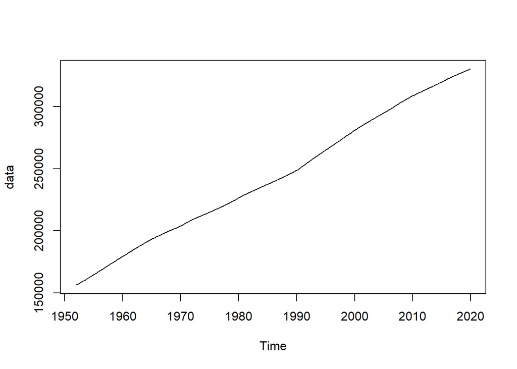

```r
ts.plot(data)
```

# INTERPRETATION The time series plot of the data is obtained and we can observe that the data consist of trend component (Constantly increasing nature) and random component and not the seasonal component (No predictive and repetitive nature). Hence the mathematical model of the data is additive in nature.

# 4. Checking the stationarity of the data - ADF Test

### H0 : the data set comes from a non-stationary process

### H1: the data set comes from a stationary process

```r
adf.test(data)
```

```
##
##  Augmented Dickey-Fuller Test
##
## data:  data
## Dickey-Fuller = -2.2811, Lag order = 9, p-value = 0.4593
## alternative hypothesis: stationary
```

# INTERPRETATION

ADF test is done for checking stationarity. p-value = 0.4593 > 0.05. Hence we are not rejecting H0. The data set is coming from a non-stationary process.

# 5. Steps invoved in extracting the stationary version of the data

```r
#STEP 1 : Creating a time variable
t = seq(1:length(data))

#STEP 2 : Fitting a linear regression model
model = lm(data~t)
model
```

```
##
## Call:
## lm(formula = data ~ t)
##
## Coefficients:
## (Intercept)            t
##    156400.0        214.1
```

```r
#STEP 3 : Extracting the residuals and checking for stationarity
res = resid(model)
adf.test(res)
```

```
##
##  Augmented Dickey-Fuller Test
##
## data:  res
## Dickey-Fuller = -2.2811, Lag order = 9, p-value = 0.4593
## alternative hypothesis: stationary
```

```r
#STEP 4 : Creating a second order variable and checking for stationarity
t_2 = t^2
model2 = lm(data ~ t+t_2)
model2
```

```
##
## Call:
## lm(formula = data ~ t + t_2)
##
## Coefficients:
## (Intercept)            t          t_2
##   1.596e+05    1.907e+02    2.857e-02
```

```r
res2 = resid(model2)
adf.test(res2)
```

```
##
##  Augmented Dickey-Fuller Test
##
## data:  res2
## Dickey-Fuller = -2.2686, Lag order = 9, p-value = 0.4646
## alternative hypothesis: stationary
```

```r
#STEP 5 : Repeating the steps until stationarity is obtained
t_3 = t^3
model3 = lm(data ~ t+t_2+t_3)
model3
```

```
##
## Call:
## lm(formula = data ~ t + t_2 + t_3)
##
## Coefficients:
## (Intercept)            t          t_2          t_3
##   1.592e+05    1.965e+02    1.078e-02    1.451e-05
```

```r
res3 = resid(model3)
adf.test(res3)
```

```
##
##  Augmented Dickey-Fuller Test
##
## data:  res3
## Dickey-Fuller = -2.1473, Lag order = 9, p-value = 0.516
## alternative hypothesis: stationary
```

```r
#4th order
t_4 = t^4
model4 = lm(data ~ t+t_2+t_3+t_4)
model4
```

```
##
## Call:
## lm(formula = data ~ t + t_2 + t_3 + t_4)
##
## Coefficients:
## (Intercept)            t          t_2          t_3          t_4
##   1.534e+05    3.370e+02   -7.619e-01    1.485e-03   -9.000e-07
```

```r
res4 = resid(model4)
adf.test(res4)
```

```
##
##  Augmented Dickey-Fuller Test
##
## data:  res4
## Dickey-Fuller = -3.3193, Lag order = 9, p-value = 0.06736
## alternative hypothesis: stationary
```

```r
#5th order
t_5 = t^5
model5 = lm(data ~ t+t_2+t_3+t_4+t_5)
model5
```

```
##
## Call:
## lm(formula = data ~ t + t_2 + t_3 + t_4 + t_5)
##
## Coefficients:
## (Intercept)            t          t_2          t_3          t_4          t_5
##   1.540e+05    3.147e+02   -5.708e-01    8.619e-04   -4.200e-08   -4.201e-10
```

```r
res5 = resid(model5)
adf.test(res5)
```

```
##
##  Augmented Dickey-Fuller Test
##
## data:  res5
## Dickey-Fuller = -3.0153, Lag order = 9, p-value = 0.1485
## alternative hypothesis: stationary
```

```r
#6th order
t_6 = t^6
model6 = lm(data ~ t+t_2+t_3+t_4+t_5+t_6)
model6
```

```
##
## Call:
## lm(formula = data ~ t + t_2 + t_3 + t_4 + t_5 + t_6)
##
## Coefficients:
## (Intercept)            t          t_2          t_3          t_4          t_5
##   1.562e+05    2.050e+02    7.673e-01   -5.679e-03    1.496e-05   -1.657e-08
##         t_6
##   6.591e-12
```

```r
res6 = resid(model6)
adf.test(res6)
```

```
##
##  Augmented Dickey-Fuller Test
##
## data:  res6
## Dickey-Fuller = -3.6147, Lag order = 9, p-value = 0.03127
## alternative hypothesis: stationary
```

# INTERPRETATION

In order to transform the data into stationary series, method of least square is performed. For this in the first step a first order time variable is created and data is fitted into a linear regression model using this variable. Then residual of the model is extracted and checked for stationarity using ADF test. The data exhibited non-stationary behaviour. Hence a second order time variable is created and the same procedure was repeated until stationarity of the data is obtained. Here at the 6th level stationarity of the data is obtained (p-value = 0.0312 < 0.05).

# CONCLUSION

The chosen data was a time series data with trend component and it came from a non-stationary series. Method of least square was applied to extract the stationary version of the data and on the 6th step of model fitting the data attained stationarity with a p-value = 0.03127.